# Go Bike Trip Data

### By: Muneera Alshunaifi

## Preliminary Wrangling

```python
# import all packages and set plots to be embedded inline
import numpy as np
import pandas as pd
import matplotlib.pyplot as plt
import seaborn as sb
from datetime import date
import time

%matplotlib inline
```

```python
# load in the dataset into a pandas dataframe, print statistics
bikes = pd.read_csv('201902-fordgobike-tripdata.csv')
```

```python
# high-level overview of data shape and composition
print(bikes.shape)
```

```
(183412, 16)
```

```python
bikes.sample(20)
```

|  | duration_sec | start_time | end_time | start_station_id | start_station_name | start_station_latitude | start_station_longitude | end_station_id | end_station_name | end_station_latitude | end_station_longitude | bike_id | user_type | member_birth_year | member_gender | bike_share_for_all_trip |
| --- | --- | --- | --- | --- | --- | --- | --- | --- | --- | --- | --- | --- | --- | --- | --- | --- |
| 128051 | 854 | 2019-02-10 14:03:24.7440 | 2019-02-10 14:17:39.1280 | 144.0 | Precita Park | 37.747300 | -122.411403 | 124.0 | 19th St at Florida St | 37.760447 | -122.410807 | 4803 | Customer | 1981.0 | Male | No |
| 14784 | 530 | 2019-02-27 11:06:23.5880 | 2019-02-27 11:15:13.7210 | 196.0 | Grand Ave at Perkins St | 37.808894 | -122.256460 | 198.0 | Snow Park | 37.807813 | -122.264496 | 251 | Customer | 1984.0 | Male | No |
| 146428 | 1280 | 2019-02-07 08:31:57.5410 | 2019-02-07 08:53:17.7890 | 285.0 | Webster St at O'Farrell St | 37.783521 | -122.431158 | 13.0 | Commercial St at Montgomery St | 37.794231 | -122.402923 | 2907 | Subscriber | 1960.0 | Male | No |
| 79259 | 423 | 2019-02-18 17:50:27.6440 | 2019-02-18 17:57:30.7230 | 15.0 | San Francisco Ferry Building (Harry Bridges Pl... | 37.795392 | -122.394203 | 324.0 | Union Square (Powell St at Post St) | 37.788300 | -122.408531 | 4963 | Subscriber | 1971.0 | Male | No |
| 153648 | 787 | 2019-02-06 11:59:24.5540 | 2019-02-06 12:12:32.4960 | 16.0 | Steuart St at Market St | 37.794130 | -122.394430 | 81.0 | Berry St at 4th St | 37.775880 | -122.393170 | 2227 | Subscriber | 1980.0 | Male | No |
| 48841 | 629 | 2019-02-22 06:47:56.3860 | 2019-02-22 06:58:25.4490 | 178.0 | Broadway at 30th St | 37.819381 | -122.261928 | 219.0 | Marston Campbell Park | 37.809824 | -122.280192 | 4862 | Subscriber | 1980.0 | Female | No |
| 59669 | 238 | 2019-02-20 19:49:00.6460 | 2019-02-20 19:52:58.6490 | 370.0 | Jones St at Post St | 37.787327 | -122.413278 | 368.0 | Myrtle St at Polk St | 37.785434 | -122.419622 | 6291 | Subscriber | 1981.0 | Male | No |
| 72676 | 387 | 2019-02-19 15:59:52.1040 | 2019-02-19 16:06:19.2670 | 100.0 | Bryant St at 15th St | 37.767100 | -122.410662 | 67.0 | San Francisco Caltrain Station 2 (Townsend St... | 37.776639 | -122.395526 | 6291 | Subscriber | 1988.0 | Female | No |
| 67311 | 730 | 2019-02-20 07:58:38.4300 | 2019-02-20 08:10:48.6600 | 141.0 | Valencia St at Cesar Chavez St | 37.747998 | -122.420219 | 90.0 | Townsend St at 7th St | 37.771058 | -122.402717 | 5028 | Subscriber | 1994.0 | Male | No |
| 160140 | 821 | 2019-02-05 17:14:41.7200 | 2019-02-05 17:28:23.3980 | 37.0 | 2nd St at Folsom St | 37.785000 | -122.395936 | 126.0 | Esprit Park | 37.761634 | -122.390648 | 5529 | Subscriber | 1986.0 | Female | No |
| 158626 | 371 | 2019-02-05 18:51:07.0000 | 2019-02-05 18:57:18.9760 | 182.0 | 19th Street BART Station | 37.809013 | -122.268247 | 196.0 | Grand Ave at Perkins St | 37.808894 | -122.256460 | 2544 | Subscriber | 1989.0 | Male | No |
| 37371 | 314 | 2019-02-23 14:21:10.3660 | 2019-02-23 14:26:24.8250 | 19.0 | Post St at Kearny St | 37.788975 | -122.403452 | 323.0 | Broadway at Kearny | 37.798014 | -122.405950 | 6301 | Subscriber | 1992.0 | Male | No |
| 177653 | 572 | 2019-02-01 19:47:41.0420 | 2019-02-01 19:57:13.6260 | 141.0 | Valencia St at Cesar Chavez St | 37.747998 | -122.420219 | 86.0 | Market St at Dolores St | 37.769305 | -122.426826 | 5332 | Subscriber | 1985.0 | Female | No |
| 180111 | 462 | 2019-02-01 11:59:01.2140 | 2019-02-01 12:06:43.3350 | 23.0 | The Embarcadero at Steuart St | 37.791464 | -122.391034 | 50.0 | 2nd St at Townsend St | 37.780526 | -122.390288 | 5424 | Subscriber | 1985.0 | Male | No |
| 74365 | 546 | 2019-02-19 10:39:50.6560 | 2019-02-19 10:48:57.2580 | 345.0 | Hubbell St at 16th St | 37.766483 | -122.398279 | 58.0 | Market St at 10th St | 37.776619 | -122.417385 | 5907 | Subscriber | 1988.0 | Male | No |
| 37274 | 1133 | 2019-02-23 14:18:15.6700 | 2019-02-23 14:37:09.0130 | 349.0 | Howard St at Mary St | 37.781010 | -122.405666 | 381.0 | 20th St at Dolores St | 37.758238 | -122.426094 | 5294 | Subscriber | 1996.0 | Female | No |
| 12509 | 209 | 2019-02-27 17:35:00.3280 | 2019-02-27 17:38:29.4160 | 114.0 | Rhode Island St at 17th St | 37.764478 | -122.402570 | 89.0 | Division St at Potrero Ave | 37.769218 | -122.407646 | 6372 | Subscriber | 1995.0 | Male | No |
| 86561 | 683 | 2019-02-17 12:27:34.4720 | 2019-02-17 12:38:57.7400 | 120.0 | Mission Dolores Park | 37.761420 | -122.426435 | 144.0 | Precita Park | 37.747300 | -122.411403 | 4799 | Subscriber | 1961.0 | Female | No |
| 66739 | 444 | 2019-02-20 08:32:06.8970 | 2019-02-20 08:39:30.9620 | 386.0 | 24th St at Bartlett St | 37.752105 | -122.419724 | 356.0 | Valencia St at Clinton Park | 37.769188 | -122.422285 | 5974 | Subscriber | NaN | NaN | No |
| 150735 | 550 | 2019-02-06 17:52:05.6090 | 2019-02-06 18:01:15.6810 | 13.0 | Commercial St at Montgomery St | 37.794231 | -122.402923 | 324.0 | Union Square (Powell St at Post St) | 37.788300 | -122.408531 | 5038 | Subscriber | NaN | NaN | No |

```python
bikes.dtypes
```

```
duration_sec                 int64
start_time                  object
end_time                    object
start_station_id           float64
start_station_name          object
start_station_latitude     float64
start_station_longitude    float64
end_station_id             float64
end_station_name            object
end_station_latitude       float64
end_station_longitude      float64
bike_id                      int64
user_type                   object
member_birth_year          float64
member_gender               object
bike_share_for_all_trip     object
dtype: object
```

```python
#descriptive statistics for numeric variables
bikes.describe()
```

|  | duration_sec | start_station_id | start_station_latitude | start_station_longitude | end_station_id | end_station_latitude | end_station_longitude | bike_id | member_birth_year |
| --- | --- | --- | --- | --- | --- | --- | --- | --- | --- |
| count | 183412.000000 | 183215.000000 | 183412.000000 | 183412.000000 | 183215.000000 | 183412.000000 | 183412.000000 | 183412.000000 | 175147.000000 |
| mean | 726.078435 | 138.590427 | 37.771223 | -122.352664 | 136.249123 | 37.771427 | -122.352250 | 4472.906375 | 1984.806437 |
| std | 1794.389780 | 111.778864 | 0.099581 | 0.117097 | 111.515131 | 0.099490 | 0.116673 | 1664.383394 | 10.116689 |
| min | 61.000000 | 3.000000 | 37.317298 | -122.453704 | 3.000000 | 37.317298 | -122.453704 | 11.000000 | 1878.000000 |
| 25% | 325.000000 | 47.000000 | 37.770083 | -122.412408 | 44.000000 | 37.770407 | -122.411726 | 3777.000000 | 1980.000000 |
| 50% | 514.000000 | 104.000000 | 37.780760 | -122.398285 | 100.000000 | 37.781010 | -122.398279 | 4958.000000 | 1987.000000 |
| 75% | 796.000000 | 239.000000 | 37.797280 | -122.286533 | 235.000000 | 37.797320 | -122.288045 | 5502.000000 | 1992.000000 |
| max | 85444.000000 | 398.000000 | 37.880222 | -121.874119 | 398.000000 | 37.880222 | -121.874119 | 6645.000000 | 2001.000000 |

```python
#check nulls
bikes.isna().sum()
```

```
duration_sec                  0
start_time                    0
end_time                      0
start_station_id            197
start_station_name          197
start_station_latitude        0
start_station_longitude       0
end_station_id              197
end_station_name            197
end_station_latitude          0
end_station_longitude         0
bike_id                       0
user_type                     0
member_birth_year          8265
member_gender              8265
bike_share_for_all_trip       0
dtype: int64
```

```python
#check duplicated
bikes.duplicated()
```

```
0         False
1         False
2         False
3         False
4         False
          ...
183407    False
183408    False
183409    False
183410    False
183411    False
Length: 183412, dtype: bool
```

```python
# remove unncecessary columns that are not useful for analysis
bikes = bikes.drop(['start_station_latitude', 'start_station_longitude', 'end_station_latitude', 'end_station_longitude', 'bike_share_for_all_trip'], axis=1)
bikes
```

|  | duration_sec | start_time | end_time | start_station_id | start_station_name | end_station_id | end_station_name | bike_id | user_type | member_birth_year | member_gender |
| --- | --- | --- | --- | --- | --- | --- | --- | --- | --- | --- | --- |
| 0 | 52185 | 2019-02-28 17:32:10.1450 | 2019-03-01 08:01:55.9750 | 21.0 | Montgomery St BART Station (Market St at 2nd St) | 13.0 | Commercial St at Montgomery St | 4902 | Customer | 1984.0 | Male |
| 1 | 42521 | 2019-02-28 18:53:21.7890 | 2019-03-01 06:42:03.0560 | 23.0 | The Embarcadero at Steuart St | 81.0 | Berry St at 4th St | 2535 | Customer | NaN | NaN |
| 2 | 61854 | 2019-02-28 12:13:13.2180 | 2019-03-01 05:24:08.1460 | 86.0 | Market St at Dolores St | 3.0 | Powell St BART Station (Market St at 4th St) | 5905 | Customer | 1972.0 | Male |
| 3 | 36490 | 2019-02-28 17:54:26.0100 | 2019-03-01 04:02:36.8420 | 375.0 | Grove St at Masonic Ave | 70.0 | Central Ave at Fell St | 6638 | Subscriber | 1989.0 | Other |
| 4 | 1585 | 2019-02-28 23:54:18.5490 | 2019-03-01 00:20:44.0740 | 7.0 | Frank H Ogawa Plaza | 222.0 | 10th Ave at E 15th St | 4898 | Subscriber | 1974.0 | Male |
| ... | ... | ... | ... | ... | ... | ... | ... | ... | ... | ... | ... |
| 183407 | 480 | 2019-02-01 00:04:49.7240 | 2019-02-01 00:12:50.0340 | 27.0 | Beale St at Harrison St | 324.0 | Union Square (Powell St at Post St) | 4832 | Subscriber | 1996.0 | Male |
| 183408 | 313 | 2019-02-01 00:05:34.7440 | 2019-02-01 00:10:48.5020 | 21.0 | Montgomery St BART Station (Market St at 2nd St) | 66.0 | 3rd St at Townsend St | 4960 | Subscriber | 1984.0 | Male |
| 183409 | 141 | 2019-02-01 00:06:05.5490 | 2019-02-01 00:08:27.2200 | 278.0 | The Alameda at Bush St | 277.0 | Morrison Ave at Julian St | 3824 | Subscriber | 1990.0 | Male |
| 183410 | 139 | 2019-02-01 00:05:34.3600 | 2019-02-01 00:07:54.2870 | 220.0 | San Pablo Ave at MLK Jr Way | 216.0 | San Pablo Ave at 27th St | 5095 | Subscriber | 1988.0 | Male |
| 183411 | 271 | 2019-02-01 00:00:20.6360 | 2019-02-01 00:04:52.0580 | 24.0 | Spear St at Folsom St | 37.0 | 2nd St at Folsom St | 1057 | Subscriber | 1989.0 | Male |

183412 rows × 11 columns

```python
# convert member_gender to category
bikes['member_gender'].astype('category')
```

```
0          Male
1           NaN
2          Male
3         Other
4          Male
          ...
183407     Male
183408     Male
183409     Male
183410     Male
183411     Male
Name: member_gender, Length: 183412, dtype: category
Categories (3, object): [Female, Male, Other]
```

```python
#check outliers
print('Youngest member is:',2020-bikes['member_birth_year'].max(),'years old, his birth year is:',bikes['member_birth_year'].max())
print('Oldest member is:',2020-bikes['member_birth_year'].min(),'years old, his birth year is:',bikes['member_birth_year'].min())
```

```
Youngest member is: 19.0 years old, his birth year is: 2001.0
Oldest member is: 142.0 years old, his birth year is: 1878.0
```

```python
#create age column
bikes['member_age'] = bikes['member_birth_year'].apply(lambda x: 2020 - x)

#test
bikes['member_age'].head()
```

```
0    36.0
1     NaN
2    48.0
3    31.0
4    46.0
Name: member_age, dtype: float64
```

```python
#drop not logical ages, assuming oldest age is 80.
index_names = bikes[ bikes['member_age'] > 80 ].index
bikes.drop(index_names, inplace = True)
bikes['member_age'].head()
```

```
0    36.0
1     NaN
2    48.0
3    31.0
4    46.0
Name: member_age, dtype: float64
```

```python
#convert start time to datetime
bikes['start_time']= pd.to_datetime(bikes['start_time'])
print(bikes.info())

bikes['start_time'].head()
```

```
<class 'pandas.core.frame.DataFrame'>
Int64Index: 183209 entries, 0 to 183411
Data columns (total 12 columns):
 #   Column              Non-Null Count   Dtype
---  ------              --------------   -----
 0   duration_sec        183209 non-null  int64
 1   start_time          183209 non-null  datetime64[ns]
 2   end_time            183209 non-null  object
 3   start_station_id    183012 non-null  float64
 4   start_station_name  183012 non-null  object
 5   end_station_id      183012 non-null  float64
 6   end_station_name    183012 non-null  object
 7   bike_id             183209 non-null  int64
 8   user_type           183209 non-null  object
 9   member_birth_year   174944 non-null  float64
 10  member_gender       174944 non-null  object
 11  member_age          174944 non-null  float64
dtypes: datetime64[ns](1), float64(4), int64(2), object(5)
memory usage: 18.2+ MB
None
```

```
0   2019-02-28 17:32:10.145
1   2019-02-28 18:53:21.789
2   2019-02-28 12:13:13.218
3   2019-02-28 17:54:26.010
4   2019-02-28 23:54:18.549
Name: start_time, dtype: datetime64[ns]
```

```python
#Find month of the year
import calendar
import math
import time

bikes['start_month_number'] = bikes['start_time'].apply(lambda time: time.month)
bikes['start_month_name'] = bikes['start_month_number'].apply(lambda x: calendar.month_abbr[x])

#Check
print(bikes['start_month_number'].value_counts())
print(bikes['start_month_name'].value_counts())
```

```
2    183209
Name: start_month_number, dtype: int64
Feb    183209
Name: start_month_name, dtype: int64
```

```python
#Find day period (morning, night, afternoon)

bikes['start_hour'] = bikes['start_time'].apply(lambda time: time.hour)
bikes['period_day'] = 'Morning'
bikes['period_day'][(bikes['start_hour'] >= 12) & (bikes['start_hour'] <= 17)] = 'Afternoon'
bikes['period_day'][(bikes['start_hour'] >= 18) & (bikes['start_hour'] <= 23)] = 'Night'

#Check start hour and time of day
print(bikes['start_hour'].value_counts())
print(bikes['period_day'].value_counts())
```

```
17    21852
8     21047
18    16810
9     15893
16    14147
7     10609
19     9875
15     9145
12     8710
13     8525
10     8355
14     8127
11     7873
20     6481
21     4560
6      3481
22     2916
23     1646
0       924
5       896
1       548
2       380
4       235
3       174
Name: start_hour, dtype: int64
Afternoon    70506
Morning      70415
Night        42288
Name: period_day, dtype: int64
```

```python
#Day of the week
bikes['start_weekday_number'] = bikes['start_time'].apply(lambda time: time.dayofweek)
dmap = {0:'Monday',1:'Tuesday',2:'Wednesday',3:'Thursday',4:'Friday',5:'Saturday',6:'Sunday'}
bikes['start_weekday_name'] = bikes['start_weekday_number'].map(dmap)

#Check
print(bikes['start_weekday_number'].value_counts())
print(bikes['start_weekday_name'].value_counts())
```

```
3    35174
1    31787
2    29611
4    28937
0    26799
6    15503
5    15398
Name: start_weekday_number, dtype: int64
Thursday     35174
Tuesday      31787
Wednesday    29611
Friday       28937
Monday       26799
Sunday       15503
Saturday     15398
Name: start_weekday_name, dtype: int64
```

```python
#convert time period, month, and weekday to category.

ordinal_var_dict = {'start_month_name': ['June','July','August','September','October','November','December'],
                    'period_day': ['Morning', 'Afternoon', 'Night'],
                    'start_weekday_name': ['Monday', 'Tuesday', 'Wednesday', 'Thursday', 'Friday', 'Saturday', 'Sunday']}

for var in ordinal_var_dict:
    ordered_var = pd.api.types.CategoricalDtype(ordered = True,
                                                categories = ordinal_var_dict[var])
    bikes[var] = bikes[var].astype(ordered_var)
```

### What is/are the main feature(s) of interest in your dataset?

I'm most interested in figuring out what features are best for predicting the duration of the trip. Here are some questions I want to extract its answers from dataset:

- When and where most trips taken?
- Do Age and Sex , user type affect the duration and the locations?

### What features in the dataset do you think will help support your investigation into your feature(s) of interest?

I expect that specific stations will have more bike rides rather than other stations and thats because of the station location, Also I am expecting that morning and afternoon rides are more than night rides due to rush hours. Also, I assume younger riders are more than older riders because of physical abilities. Moreover, I think that the other features: user type and sex will have effects on the duration.

## Univariate Exploration

I'll start by looking at the distribution of the main variable of interest: time and start location

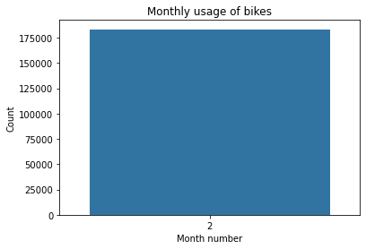

```python
#Time by months
base_color = sb.color_palette()[0]

sb.countplot(data=bikes, x='start_month_number', color=base_color)
plt.xlabel('Month number')
plt.ylabel('Count')
plt.title('Monthly usage of bikes');
plt.show()
```

We can see from above figure that all bike rides are only taken in 2nd Month which is (Febrauary).

```python
#keep only top 8 locations with high traffics
locs = ['San Francisco Ferry Building (Harry Bridges Plaza)','The Embarcadero at Sansome St','San Francisco Caltrain (Townsend St at 4th St)','San Francisco Caltrain Station 2  (Townsend St at 4th St)','Market St at 10th St','Montgomery St BART Station (Market St at 2nd St)','Berry St at 4th St','Powell St BART Station (Market St at 4th St)']
bikes_top_st = bikes.loc[bikes['start_station_name'].isin(locs)]

#check
bikes_top_st['start_station_name'].value_counts()
```

```
Market St at 10th St                                         3903
San Francisco Caltrain Station 2  (Townsend St at 4th St)    3529
Berry St at 4th St                                           3050
Montgomery St BART Station (Market St at 2nd St)             2893
Powell St BART Station (Market St at 4th St)                 2760
San Francisco Ferry Building (Harry Bridges Plaza)           2708
San Francisco Caltrain (Townsend St at 4th St)               2695
The Embarcadero at Sansome St                                2082
Name: start_station_name, dtype: int64
```

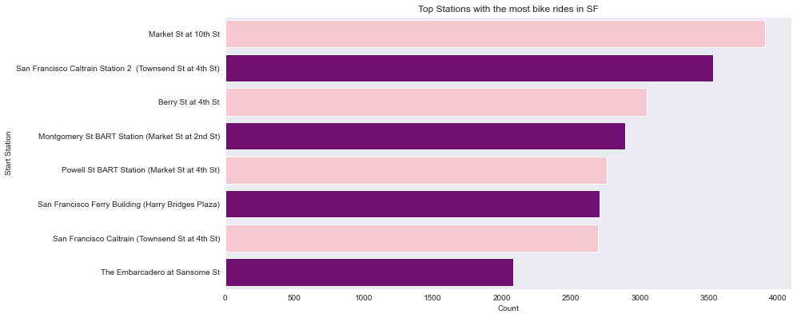

```python
station_counts = bikes_top_st['start_station_name'].value_counts()
station_order = station_counts.index

sb.set_style("dark")
plt.figure(figsize=[12.7,6.27])
sb.countplot(data=bikes_top_st, y='start_station_name', palette=['pink','purple'], order=station_order)
plt.xlabel('Count')
plt.ylabel('Start Station')
plt.title('Top Stations with the most bike rides in SF');
```

- Most stations in San Francisco connect to public transportations.
- The Embarcadero at Sansome St is located in financial distrit.
- Market St at 10th St and Berry St at 4th St are also closed to Bart station

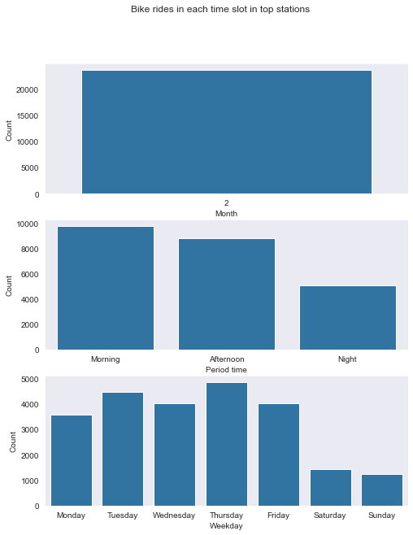

```python
months = ['Jul','Aug','Sep','Oct','Nov','Dec']
month2 = pd.api.types.CategoricalDtype(ordered=True, categories=months)
bikes_top_st['start_month_name'] = bikes_top_st['start_month_name'].astype(month2)

fig, ax = plt.subplots(nrows=3, figsize = [8,10])
default_color = sb.color_palette()[0]
sb.countplot(data = bikes_top_st, x = 'start_month_number', color = default_color, ax = ax[0])
sb.countplot(data = bikes_top_st, x = 'period_day', color = default_color, ax = ax[1])
sb.countplot(data = bikes_top_st, x = 'start_weekday_name', color = default_color, ax = ax[2])
ax[0].set_xlabel('Month')
ax[0].set_ylabel('Count')
ax[1].set_xlabel('Period time')
ax[1].set_ylabel('Count')
ax[2].set_xlabel('Weekday')
ax[2].set_ylabel('Count')
fig.suptitle('Bike rides in each time slot in top stations');
```

From above figures, we can see some findings regarding top 8 stations:

- Bike ridess are all in 2nd month (Febrauary)
- Bike rides mostly in Mornings, I think because they go to work using bikes to avoid rush hours and arrive quickly to work.
- Bike rides are rare in weekends, riders mostly ride bikes to go to thier work, thats why rest of weekdays are more rides than week end days.

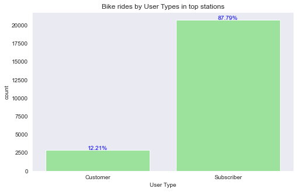

```python
# plot distribution of user type
plt.figure(figsize=[8, 5])
sb.countplot(data =  bikes_top_st, x = 'user_type', color = 'lightgreen')

points =  bikes_top_st.shape[0]
usercounts =  bikes_top_st['user_type'].value_counts()
locs, labels = plt.xticks()

# print frequency on the bar chart
for loc, label in zip(locs, labels):
    count = usercounts[label.get_text()]
    pct_string = '{:0.2f}%'.format(100*count/points)
    plt.text(loc, count-8, pct_string, ha='center', color='b')

plt.title('Bike rides by User Types in top stations')
plt.xlabel('User Type')

plt.show()
```

From above figure we can find that 87.79% of user types are Subscriber or Member and the rest of users are Customer or casual, i think thats because of the pricing page where Subscribers pay less than Customers.

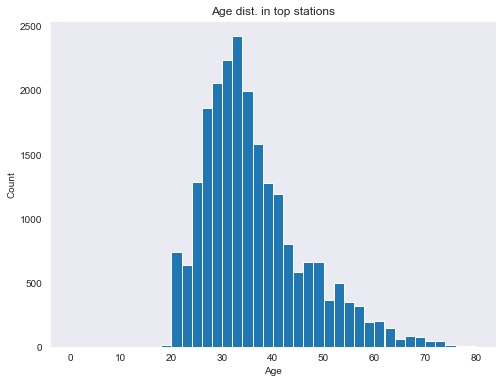

```python
#Age plotting

plt.figure(figsize=(8,6))
bins = np.arange(0,  bikes_top_st['member_age'].max()+2, 2)
plt.hist(data= bikes_top_st, x='member_age', bins=bins)
plt.xlabel('Age')
plt.ylabel('Count')
plt.title('Age dist. in top stations');
```

From above figure, we can find that age distribution is right skewed, when the age increases, the user counts decreases. that is because oldest people don't often ride bikes due to physical abilities.

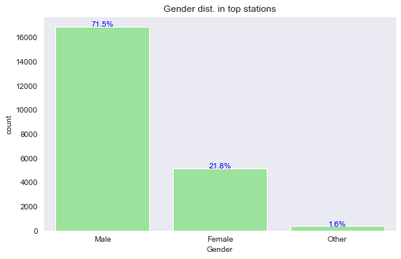

```python
plt.figure(figsize=[8, 5])

#base_color = sb.color_palette()[0]
sb.set_style("dark")

gender_order = bikes['member_gender'].value_counts().index
sb.countplot(data =  bikes_top_st, x = 'member_gender', color = 'lightgreen', order=gender_order)
plt.title('Gender dist. in top stations')
plt.xlabel('Gender')

points =  bikes_top_st.shape[0]
gender_counts =  bikes_top_st['member_gender'].value_counts()
locs, labels = plt.xticks()

for loc, label in zip(locs, labels):
    count = gender_counts[label.get_text()]
    pct_string = '{:0.1f}%'.format(100*count/points)
    plt.text(loc, count-8, pct_string, ha='center', color='blue')

plt.show()
```

From above figure, we can find that most bike riders are Male with 71.5% while Female are only 21.8%.

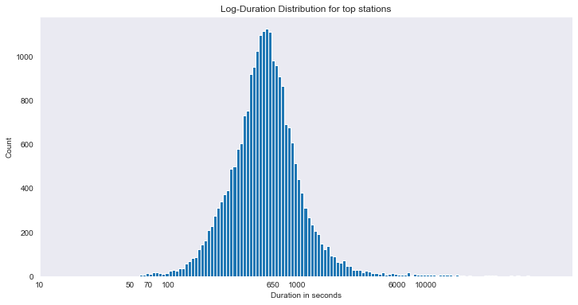

```python
#long scale dist. for duration in seconds

log_binsize = 0.025
bins = 10 ** np.arange(1.2, np.log10(bikes_top_st['duration_sec'].max())+log_binsize, log_binsize)

plt.figure(figsize=[12, 6])
plt.hist(data = bikes_top_st, x = 'duration_sec', bins = bins)
plt.xscale('log')
plt.xticks([10,50,70,100,650,1000,6000,10000], [10,50,70,100,650,1000,6000,10000])
plt.xlabel('Duration in seconds')
plt.ylabel('Count')
plt.title('Log-Duration Distribution for top stations');
```

From the figure above, we can see that its normally distributed, also most durations of trips fall into 650 seconds which equals approximately 11 minutes.

```python
#save data for top stations to do rest of explortion
bikes_top_st.to_csv("2017-fordgobike-tripdata-clean.csv", index=False)
```

### Discuss the distribution(s) of your variable(s) of interest. Were there any unusual points? Did you need to perform any transformations?

Member age distribution has one big peak between 30 and 40 years old and some small peak, yet it seems right skewed. Log-duration data looks like unimodel with one peak between 550 and 650 seconds.

### Of the features you investigated, were there any unusual distributions? Did you perform any operations on the data to tidy, adjust, or change the form of the data? If so, why did you do this?

When investigating dataset before visualization part, we found out that there is un logical ages (outliers) in the column of member_age, so we have dropped these ages to perfrorm well visualization. also we create weekdays number,names columns and month number,name columns and period time column , that is because we are interested in the time of ride bikes. and when plotting these features we find some analysis that helped us. Also we find that traffic locations is interesting feasture. So after looking into trips count in each station, we pick up top stations and stor it in bikes_top_st, stations are:

- San Francisco Ferry Building (Harry Bridges Plaza)
- The Embarcadero at Sansome St
- San Francisco Caltrain (Townsend St at 4th St)
- San Francisco Caltrain Station 2 (Townsend St at 4th St)
- Market St at 10th St
- Montgomery St BART Station (Market St at 2nd St)
- Berry St at 4th St
- Powell St BART Station (Market St at 4th St)

## Bivariate Exploration

To start off with, I want to look at the pairwise correlations present between features in the data.

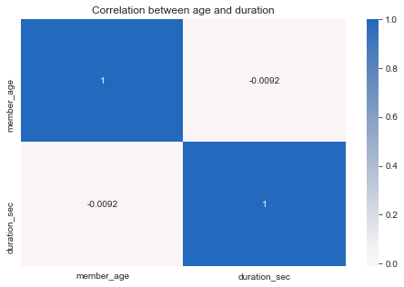

```python
numerics=['member_age','duration_sec']
plt.figure(figsize = [8, 5])
sb.heatmap(bikes_top_st[numerics].corr(), annot = True,
           cmap = 'vlag_r', center = 0)
plt.title('Correlation between age and duration');
```

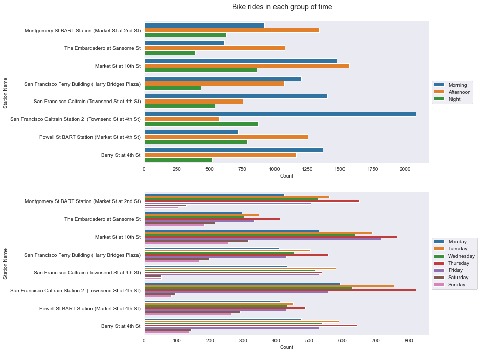

```python
Timegroup = ['period_day','start_weekday_name']
fig = plt.figure(figsize=(10,16))
plt.subplots_adjust(top=0.95)
fig.suptitle('Bike rides in each group of time', fontsize=14)

for i in range(1, 3):
    ax = fig.add_subplot(3, 1, i)
    sb.countplot(data=bikes_top_st, y='start_station_name', hue=Timegroup[i-1])
    plt.legend(loc='center left', bbox_to_anchor=(1,0.5))
    plt.ylabel('Station Name')
    plt.xlabel('Count');
```

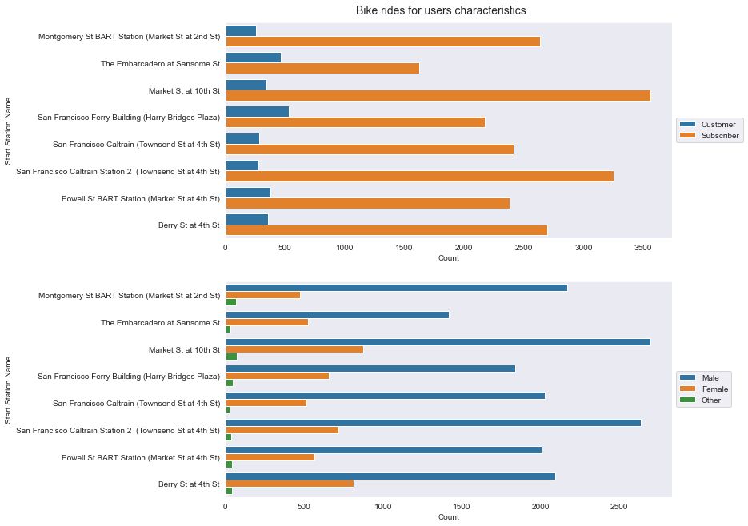

```python
charcteristics = ['user_type','member_gender']

fig = plt.figure(figsize=(10,10))
plt.subplots_adjust(top=0.95)
fig.suptitle('Bike rides for users characteristics' , fontsize=14)
for i in range(1, 3):
    ax = fig.add_subplot(2, 1, i)
    sb.countplot(data=bikes_top_st, y='start_station_name', hue=charcteristics[i-1])
    plt.legend(loc='center left', bbox_to_anchor=(1,0.5))
    plt.ylabel('Start Station Name')
    plt.xlabel('Count');
```

Subscribers are more than customers in each station. However, there are more customers at San Francisco Ferry Building (Harry Bridges Plaza) and The Embarcadero at Sansome St stations than at other stations. Customers might include tourists. The trips in male riders are way more than in females. Even though I look into the gender distribution in SF it cannot explain why males are more than females.

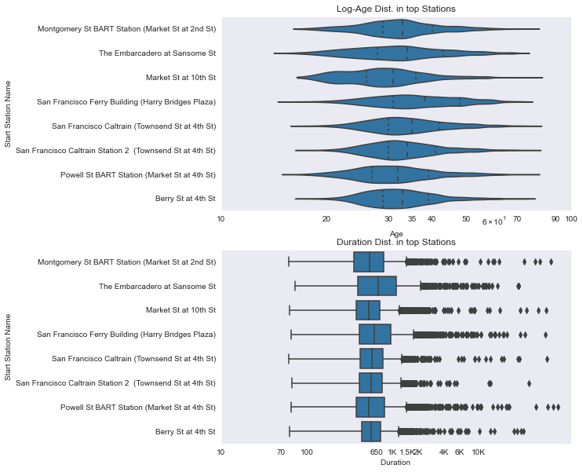

```python
plt.figure(figsize=(8,10))
base_color = sb.color_palette()[0]
ax = plt.subplot(211)
sb.violinplot(data=bikes_top_st, y='start_station_name', x='member_age', inner='quartile', color=base_color)
plt.xscale('log')
plt.xticks([10,20,30,35,40,50,70,90,100], [10,20,30,35,40,50,70,90,100])
plt.ylabel('Start Station Name')
plt.xlabel('Age')
plt.title('Log-Age Dist. in top Stations')

ax = plt.subplot(212)
sb.boxplot(data=bikes_top_st, y='start_station_name', x='duration_sec',color=base_color)
plt.xscale('log')
plt.xticks([10,50,100,650,1000,1500,2000,4000,6000,10000], [10,70,100,650,'1K','1.5K','2K','4K','6K','10K'])
plt.xlabel('Duration ')
plt.ylabel('Start Station Name')
plt.title('Duration Dist. in top Stations');
```

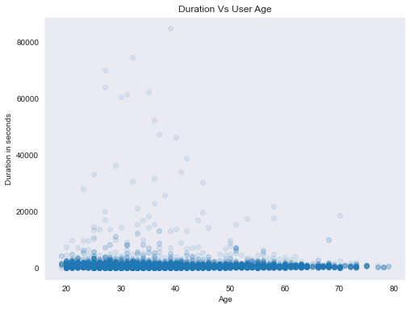

```python
# scatter plot of duration vs. age

#sb.violinplot(data=bikes_top_st, y='start_station_name', x='member_age', inner='quartile', color=base_color)
plt.figure(figsize = [8, 6])
plt.scatter(data = bikes_top_st, x = 'member_age', y = 'duration_sec', alpha = 1/10)
plt.xlabel('Age')
#plt.xlim(18, 60)
plt.ylabel('Duration in seconds')
plt.title('Duration Vs User Age')
plt.show()
```

Users with age of 25 to 45 seem to have the highest trip duration and as the users get older, the trip duration becomes less.

## Multivariate Exploration

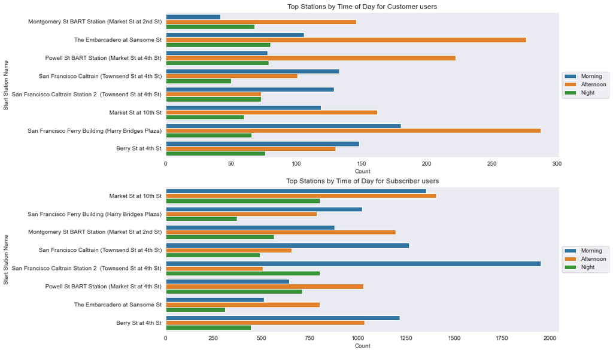

```python
#explore time period for each variable of user type

customers= bikes_top_st.query('user_type == "Customer"')
subscribers= bikes_top_st.query('user_type == "Subscriber"')

plt.figure(figsize=(12,10))
ax = plt.subplot(211)
sb.countplot(data=customers, y='start_station_name', hue='period_day')
plt.legend(loc='center left', bbox_to_anchor=(1,0.5))
plt.title('Top Stations by Time of Day for Customer users')
plt.xlabel('Count')
plt.ylabel('Start Station Name')

ax = plt.subplot(212)
sb.countplot(data=subscribers, y='start_station_name', hue='period_day')
plt.legend(loc='center left', bbox_to_anchor=(1,0.5))
plt.title('Top Stations by Time of Day for Subscriber users')
plt.xlabel('Count')
plt.ylabel('Start Station Name');
```

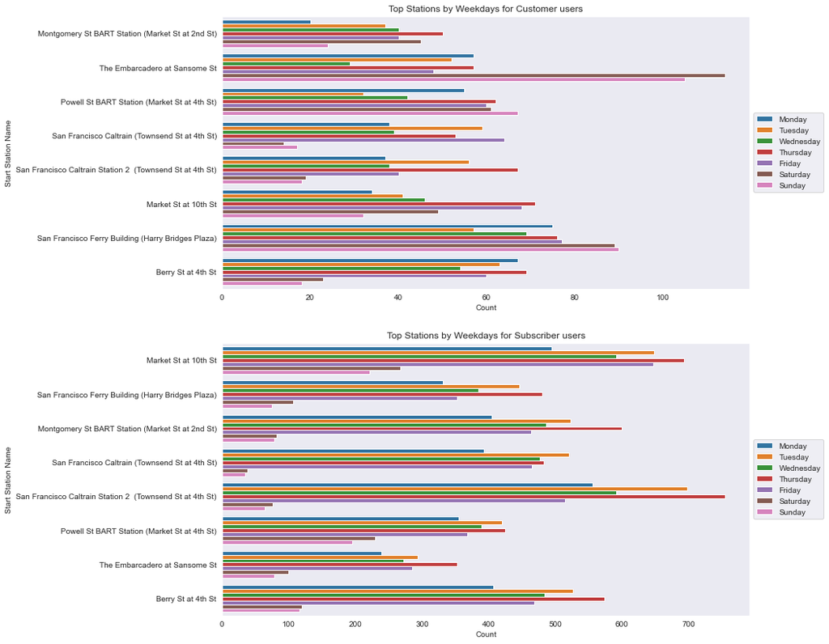

```python
plt.figure(figsize=(12,14))
ax = plt.subplot(211)
sb.countplot(data=customers, y='start_station_name', hue='start_weekday_name')
plt.legend(loc='center left', bbox_to_anchor=(1,0.5))
plt.title('Top Stations by Weekdays for Customer users')
plt.ylabel('Start Station Name')
plt.xlabel('Count')

ax = plt.subplot(212)
sb.countplot(data=subscribers, y='start_station_name', hue='start_weekday_name')
plt.legend(loc='center left', bbox_to_anchor=(1,0.5))
plt.title('Top Stations by Weekdays for Subscriber users')
plt.ylabel('Start Station Name')
plt.xlabel('Count');
```

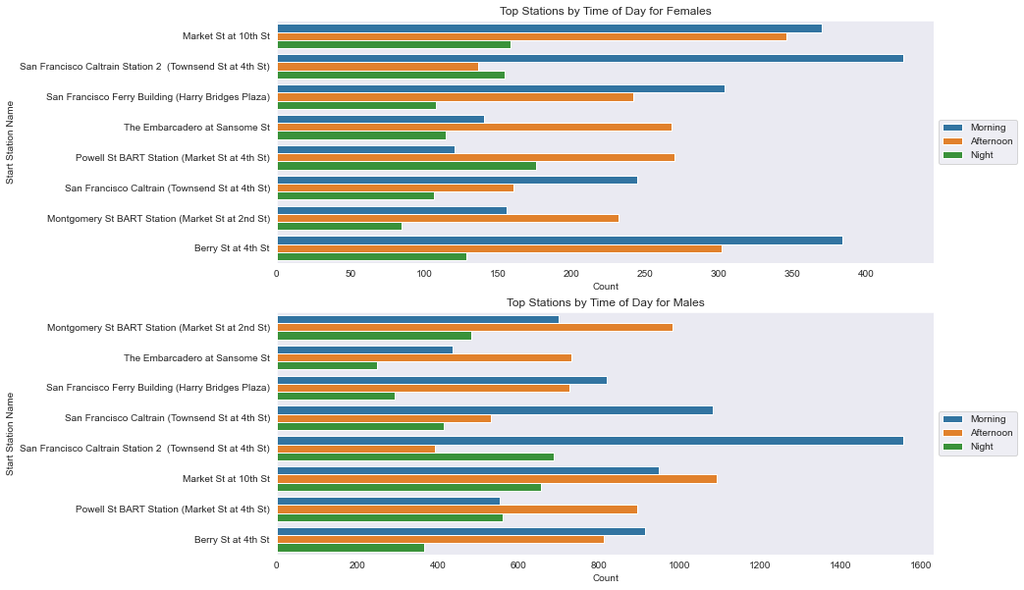

```python
#now lets explore same features but for each gender

F=bikes_top_st.query('member_gender == "Female"')
M=bikes_top_st.query('member_gender == "Male"')

plt.figure(figsize=(12,10))
ax = plt.subplot(211)
sb.countplot(data=F, y='start_station_name', hue='period_day')
plt.legend(loc='center left', bbox_to_anchor=(1,0.5))
plt.title('Top Stations by Time of Day for Females')
plt.xlabel('Count')
plt.ylabel('Start Station Name')

ax = plt.subplot(212)
sb.countplot(data=M, y='start_station_name', hue='period_day')
plt.legend(loc='center left', bbox_to_anchor=(1,0.5))
plt.title('Top Stations by Time of Day for Males')
plt.xlabel('Count')
plt.ylabel('Start Station Name');
```

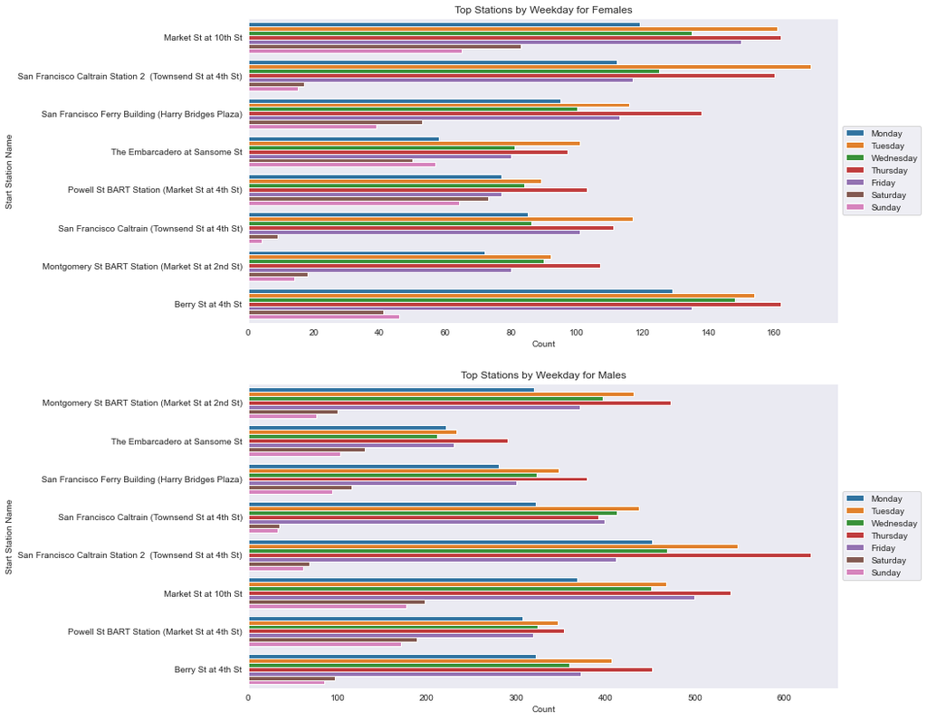

```python
#now using week days
plt.figure(figsize=(12,14))
ax = plt.subplot(211)
sb.countplot(data=F, y='start_station_name', hue='start_weekday_name')
plt.legend(loc='center left', bbox_to_anchor=(1,0.5))
plt.title('Top Stations by Weekday for Females')
plt.xlabel('Count')
plt.ylabel('Start Station Name')

ax = plt.subplot(212)
sb.countplot(data=M, y='start_station_name', hue='start_weekday_name')
plt.legend(loc='center left', bbox_to_anchor=(1,0.5))
plt.title('Top Stations by Weekday for Males')
plt.xlabel('Count')
plt.ylabel('Start Station Name');
```

```python
bikes_top_st.groupby('start_station_name')['start_station_id'].value_counts()
```

```
start_station_name                                         start_station_id
Berry St at 4th St                                         81.0                3050
Market St at 10th St                                       58.0                3903
Montgomery St BART Station (Market St at 2nd St)           21.0                2893
Powell St BART Station (Market St at 4th St)               3.0                 2760
San Francisco Caltrain (Townsend St at 4th St)             30.0                2695
San Francisco Caltrain Station 2  (Townsend St at 4th St)  67.0                3529
San Francisco Ferry Building (Harry Bridges Plaza)         15.0                2708
The Embarcadero at Sansome St                              6.0                 2082
Name: start_station_id, dtype: int64
```

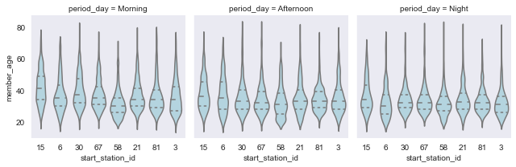

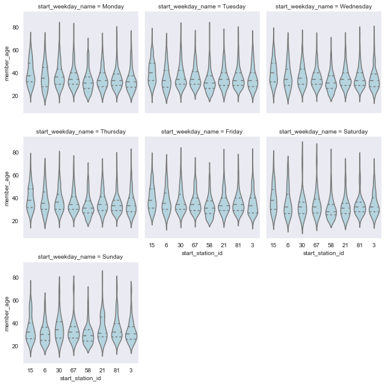

```python
# Categorical variables and 1 numeric variable: too many groups here,
# So separate them by using FacetGrid with Violin plot

# Top station by times (time of day, weekdays, months) in age distribution

for i in range(1, 3):
    g = sb.FacetGrid(data=bikes_top_st, col=Timegroup[i-1], col_wrap=3)
    g.map(sb.violinplot,'start_station_id', 'member_age', inner='quartile', order=[15,6,30,67,58,21,81,3], color='lightblue');
```

In the age distribution, there are not much different in time and locations. Most medians of age fall between 30 and 40 years old.

### Were there any interesting or surprising interactions between features?

```python
#save data for top stations to do rest of explortion

bikes_top_st.to_csv('final_data.csv')
```

```python
!jupyter nbconvert Exploration_Project_Gobike_part2.ipynb --to slides --post serve --template output_toggle
```

[output not shown]